# BMIN503/EPID600 Project Template

## **Results**

I mapped social determinants of health, COVID epidemiology, and election results and then created regression models to assess associations.

### Mapping Socioeconomic Factors, COVID-19 Epidemiology, and 2020 Presidential Election Results

I spatially mapped numerous socioeconomic factors from the Social Vulnerability Index, COVID-19 cases and deaths, and election results by county in one of the critical swing states in the 2020 Presidential election, Pennsylvania.

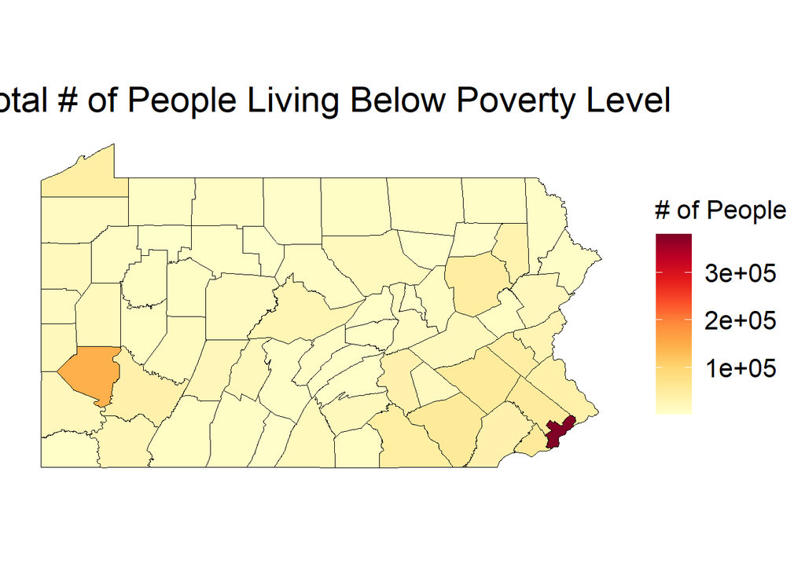

The above map shows the total number of people living in poverty at the county level. The county with the highest number of people living in poverty is Philadelphia county (380,873 people) followed by Allegheny county (144,842 people). Those are also the two most populous counties in Pennsylvania (PA) with 1,584,138 and 1,218,452 people, respectively. Philadelphia county contains the city of Philadelphia, and Allegheny county contains the city of Pittsburgh, two large metropolitan centers in PA.

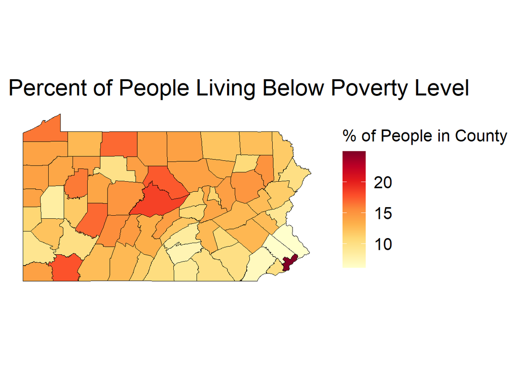

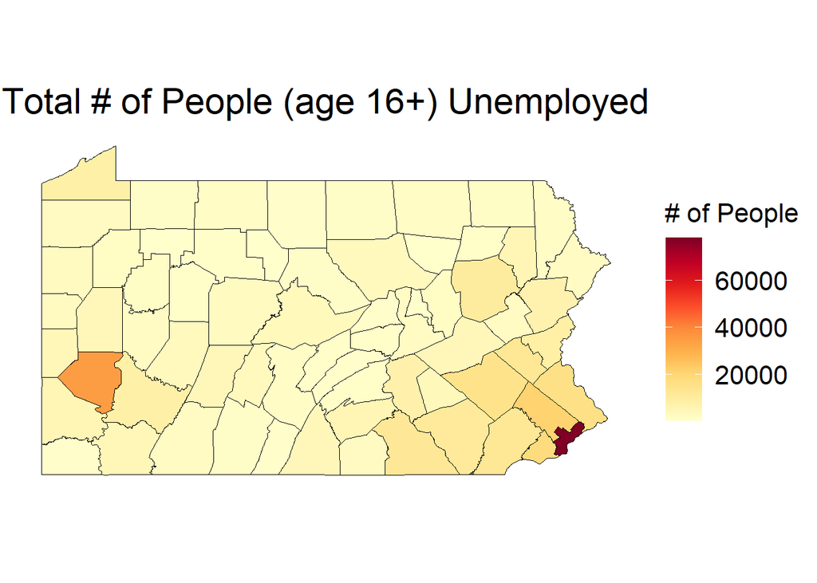

The above map shows the total number of people (age 16+) unemployed at the county level. The county with the highest number of people (age 16+) is Philadelphia county (78,170 people) followed by Allegheny county (34,903 people).

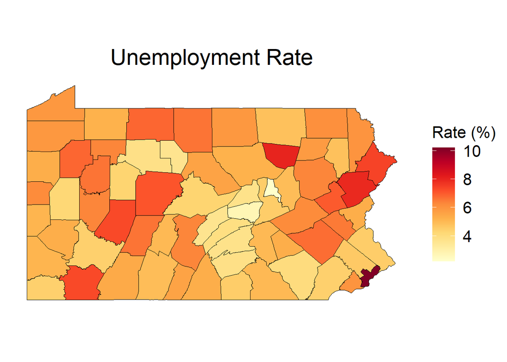

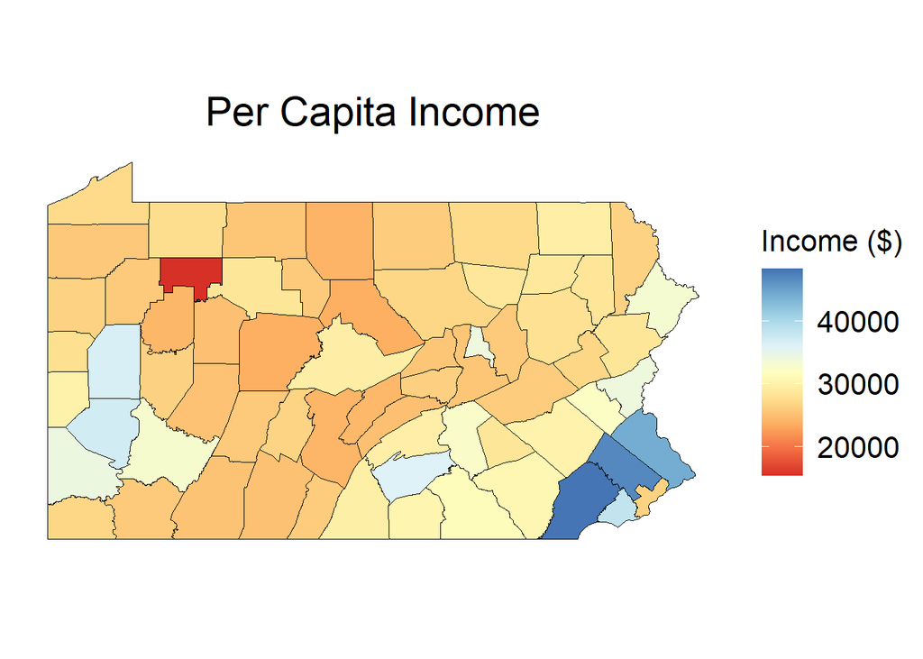

The above map shows the per capita income by county in PA. Chester, Montgomery, and Bucks counties, all which suburbs of Philadelphia, have the highest per capita income values. The lowest per capita income values are in Forest, Clearfield, and Clinton counties.

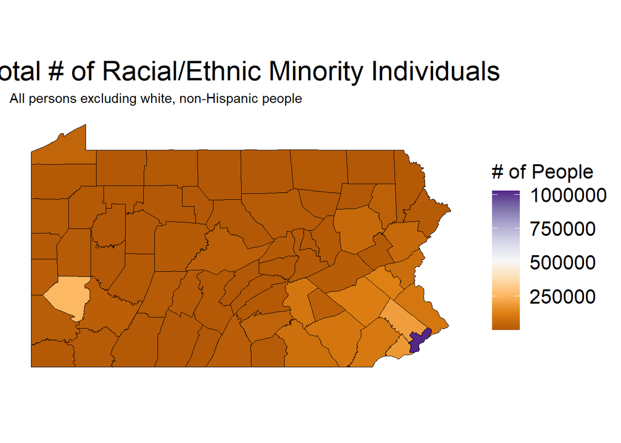

The above map shows the estimate of total number of people who are minorities, or all persons except white, non-Hispanic, at the county level. The county with the highest estimated number of minorities is Philadelphia county (1,029,738 people).

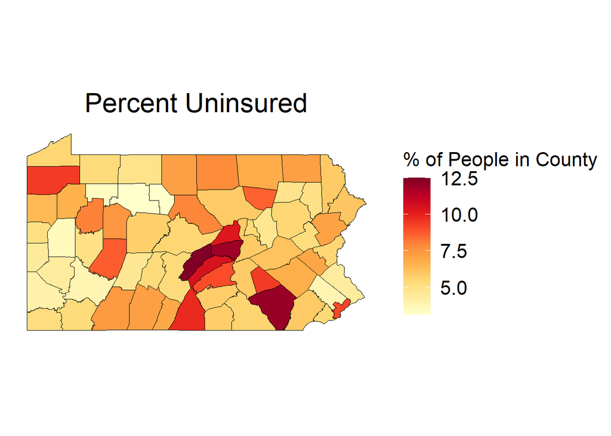

The above map shows the estimate of the percent of people uninsured in the civilian non-institutionalized population at the county level. Mifflin (12.5%), Lancaster(12.0%), and Snyder (11.9%) counties have the highest percent uninsured.

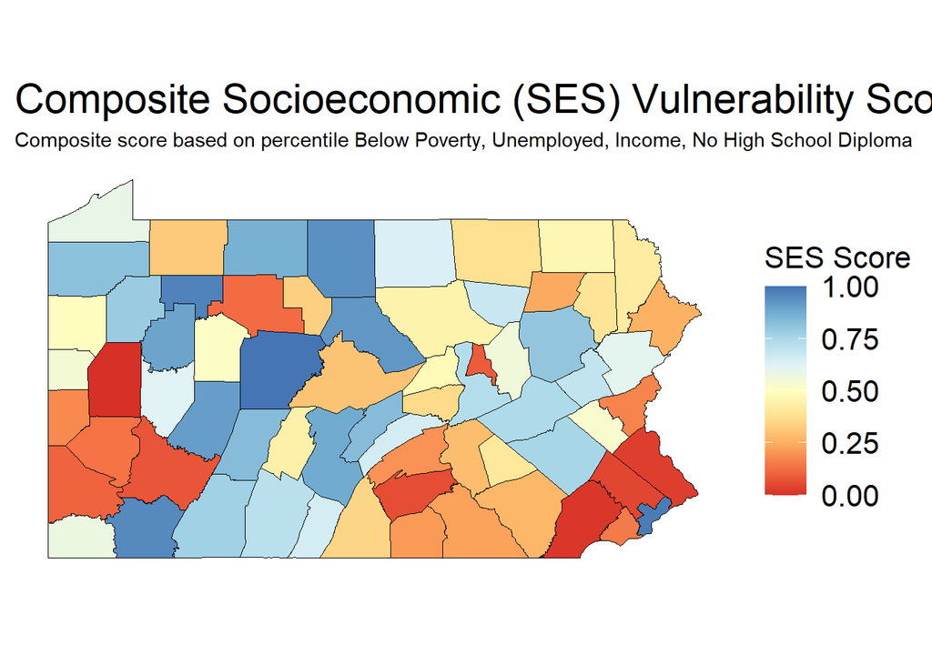

The above map shows the composite Socioeconomic Vulnerability Score from the SVI based on percentile of the following social factors: Below Poverty, Unemployed, Income, and No High School Diploma. Blue-shaded areas indicate greater relative socioeconomic vulnerability. Clearfield County in Central PA had the highest score, followed by Philadelphia, Fayette, and Forest counties.

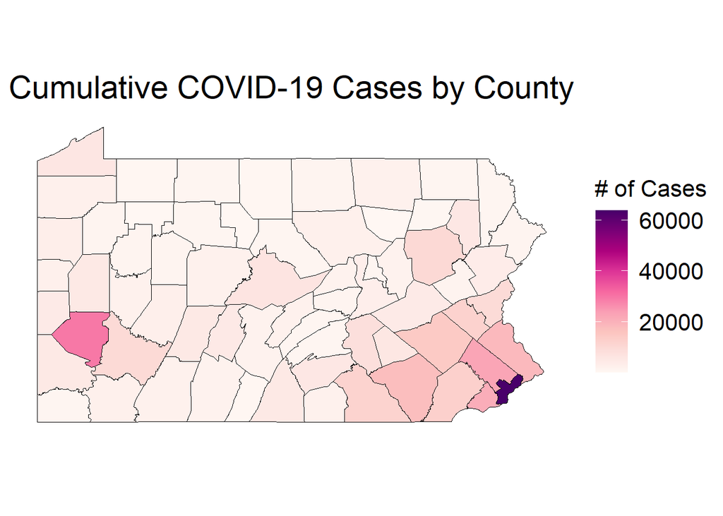

The above map shows the total number cases of COVID-19 at the county level. The county with the highest number of COVID-19 cases is Philadelphia county (63,719 cases) followed by Allegheny county (29,515 cases).

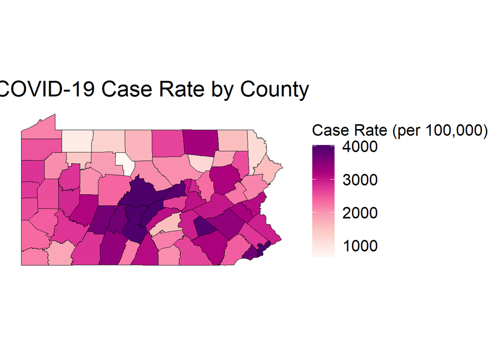

The above map shows the cumulative case rate, or number of cumulative confirmed and probable cases reported through December 1,2020 per 100,000 population, of COVID-19 at the county level. The counties with the highest cumulative case rates are Mifflin, Philadelphia, and Centre counties with case rates 4026.2, 4022.3, and 3975.9 per 100,000, respectively.

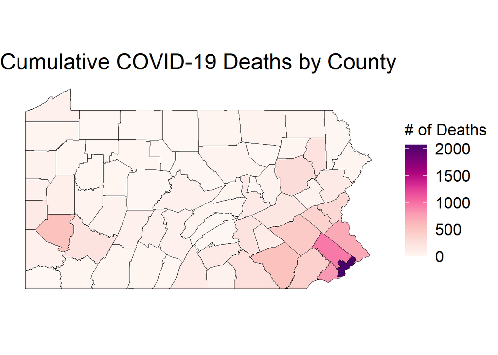

The above map shows the total number deaths of COVID-19 at the county level. The county with the highest number of COVID-19 deaths is Philadelphia county (2,065 cases) followed by Montgomery county (947 cases).

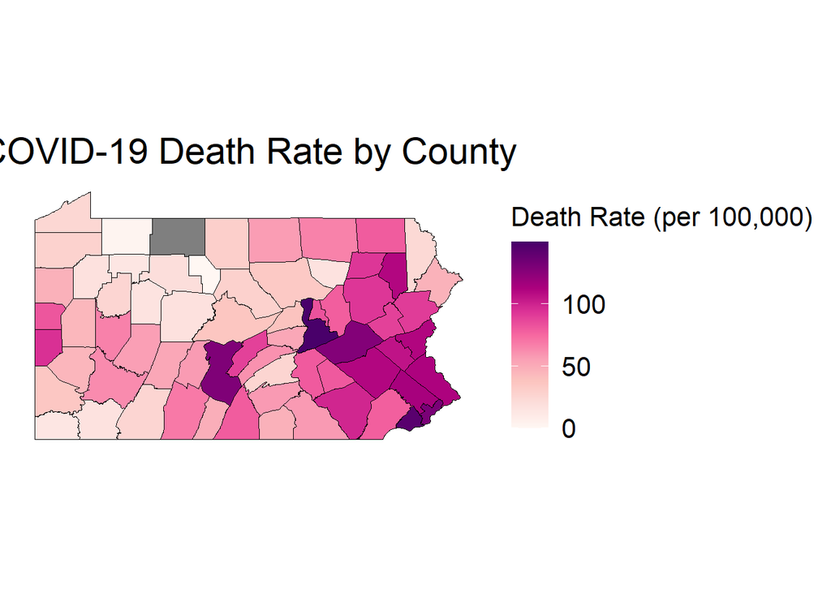

The above map shows the cumulative case rate, or total COVID-19 deaths reported through December 1,2020 per 100,000 population, of COVID-19 at the county level. The county with the highest death rate is Northumberland county (149.31 per 100,000) followed by Delaware county (142.72 per 100,000).

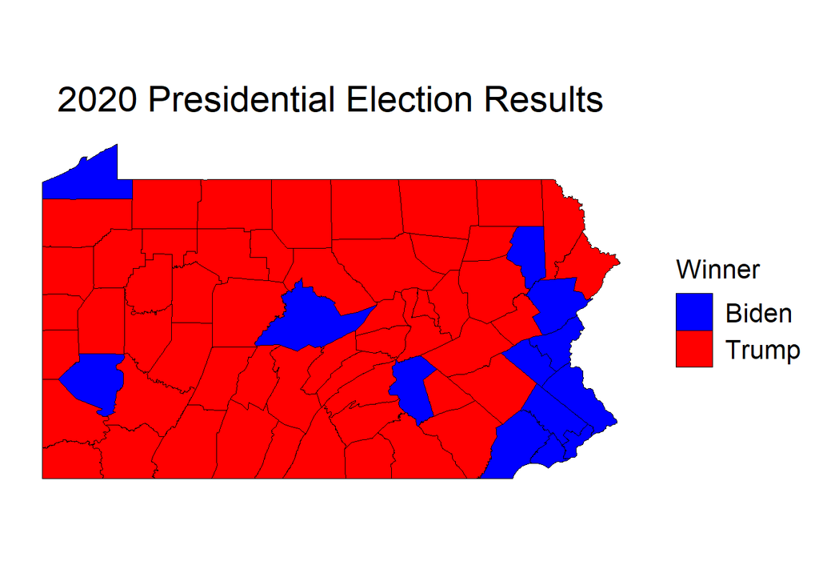

Finally, the above map shows the 2020 Presidential election results by winner (as determined by raw total votes) of that county. A blue county denotes a Joseph Biden win while a red county denotes a Donald Trump win.

####Logistic Regression Models

```r
#Printing results
multi.results %>% kbl() %>% kable_classic_2(full_width = F) %>% add_header_above(c(" ", "Table 4. Full Multivariable Logistic Regression Model Results" = 4))
```

|  | Table 4. Full Multivariable Logistic Regression Model Results OR | Table 4. Full Multivariable Logistic Regression Model Results 2.5 % | Table 4. Full Multivariable Logistic Regression Model Results 97.5 % | Table 4. Full Multivariable Logistic Regression Model Results P.value |
| --- | --- | --- | --- | --- |
| (Intercept) | 0.0000000 | 0.0000000 | 1.213089e+01 | 0.3184690 |
| Total.Poverty | 1.0007154 | 1.0001934 | NA | 0.1178648 |
| Total.Unemployment | 0.9995537 | 0.9960540 | 1.003609e+00 | 0.7539913 |
| Income.Per.Capita | 1.0004473 | 0.9995462 | 1.002406e+00 | 0.4195599 |
| Total.Minority.Persons | 1.0001678 | 1.0000075 | 1.000533e+00 | 0.1460753 |
| Socioeconomic.Status | 0.0000028 | 0.0000000 | 1.614699e+04 | 0.4075081 |
| Cumulative.Cases | 0.9930851 | NA | 9.978177e-01 | 0.0771306 |
| Cumulative.Case.Rate | 1.0088498 | 1.0021227 | NA | 0.1059640 |
| Population.2018 | 1.0000535 | 0.9999721 | 1.000283e+00 | 0.4365737 |
| Total.Deaths | 1.0846672 | 1.0046263 | 1.388000e+00 | 0.1886837 |
| Total.Death.Rate | 0.8912782 | 0.5906278 | 1.048435e+00 | 0.3585245 |

```r
socio.results %>% kbl() %>% kable_classic_2(full_width = F) %>% add_header_above(c(" ", "Table 5. Multivariable Logistic Model (Outcome: Election | Predictors: Socioeconomic) Results" = 4))
```

|  | Table 5. Multivariable Logistic Model (Outcome: Election \| Predictors: Socioeconomic) Results OR | Table 5. Multivariable Logistic Model (Outcome: Election \| Predictors: Socioeconomic) Results 2.5 % | Table 5. Multivariable Logistic Model (Outcome: Election \| Predictors: Socioeconomic) Results 97.5 % | Table 5. Multivariable Logistic Model (Outcome: Election \| Predictors: Socioeconomic) Results P.value |
| --- | --- | --- | --- | --- |
| (Intercept) | 0.0000001 | 0.0000000 | 7.073234 | 0.3184690 |
| Total.Poverty | 1.0002282 | 1.0000127 | 1.000519 | 0.1178648 |
| Total.Unemployment | 0.9996748 | 0.9981707 | 1.001030 | 0.7539913 |
| Income.Per.Capita | 1.0004624 | 0.9999181 | 1.001252 | 0.4195599 |
| Total.Minority.Persons | 1.0000678 | 1.0000004 | 1.000170 | 0.1460753 |
| Socioeconomic.Status | 0.2624756 | 0.0000038 | 6432.881202 | 0.4075081 |
| Population.2018 | 0.9999772 | 0.9999373 | 1.000007 | 0.0771306 |

```r
lm.cases.results %>% kbl() %>% kable_classic_2(full_width = F) %>% add_header_above(c(" ", "Table 6. Linear Regression Model (Outcome: Cumulative Case Rate | Predictors: Socioecnomic and Election) Results" = 2))
```

|  | Table 6. Linear Regression Model (Outcome: Cumulative Case Rate \| Predictors: Socioecnomic and Election) Results Coefficients | Table 6. Linear Regression Model (Outcome: Cumulative Case Rate \| Predictors: Socioecnomic and Election) Results P.value |
| --- | --- | --- |
| (Intercept) | 1734.9502603 | 0.0801696 |
| Total.Poverty | 0.0059452 | 0.7075811 |
| Total.Unemployment | 0.0452938 | 0.5492685 |
| Income.Per.Capita | -0.0000546 | 0.9985067 |
| Total.Minority.Persons | -0.0046441 | 0.2364417 |
| Percent.Uninsured | 140.6044786 | 0.0029912 |
| WinnerTrump | -316.1755275 | 0.3149284 |

```r
lm.deaths.results %>% kbl() %>% kable_classic_2(full_width = F) %>% add_header_above(c(" ", "Table 7. Linear Regression Model (Outcome: Total Death Rate | Predictors: Socioecnomic and Election) Results" = 2))
```

[output not shown]

## **Conclusions**

Philadelphia county seems to be one of the msot diverse counties in Pennsylvania. Philadelphia county also also has the highest amount and proportion of people unemployed and living in poverty. Many rural counties in PA have high poverty, unemployment, percent uninsured, and COVID case rates. Rural counties generally voted for Trump, while urban and suburban counties generally voted for Biden.

While many socioeconomic factors were significantly associated with election results, COVID-19 case rates, and COVID-19 death rates individually, when added to a multivariable model, only percent uninsured remaining a significant predictor for COVID-19 epidemiology at the county level.

It would be interesting to further refine variable selection and perform such analyses at a more granular geographic unit of analyses. One limitation of this study is the small sample size in the total number of counties (n = 67) in Pennsylvania, especially with a majority of those going to Trump. To increase sample size and power this study further, it would be interesting to replicate and expand these analyses to include other swing states (ex. Georgia, Michigan, Arizona, Nevada, and Wisconsin) and the whole country.